# Relationship of sex steroid hormone with lifestyle among US women

Ziqing Ye

### Overview

This project investigates how sex steroid hormone vary due to demographics, BMI, smoking habits, alchohal comsuption, physical activities using the data of sex hormone markers retrieved from NHANES 2015-2016 Demographics Data, Examination Data, Labratory Data, and Questionnaire Data. Professors that I have talked to helped me with desgining the project and how to analyze the data.

### Introduction

Unhealthy sex hormone level in women may cause many diseases, such as Polycystic Ovary Syndrome (PCOS), androgen excess and cancer. An estimated 5 to 7 million women in the united States suffer with the effects of PCOS; and PCOS can occur in girls as young as 11 years old. Androgen excess in women and the associated chronic diseases are a public health concern. The data set retrieved from NHANES could be used to assist in prevention of diseases mentioned above.

To understand how sex steroid hormone vary due to demographics, BMI, smoking habits, alchohal comsuption, physical activities, the knowledge of what sex hormone markers could be used show changes in sex steroid hormone level is require. In addition, the bioinformatics knowledge that I learned in class also helped me find the approporate data set, retrieve data set, analyze data and use the result to address the research question raised.

### Methods

The data sets used were retrieved from NANES 2015-2016 Demographics Data, Examination Data, Labratory Data, and Questionnaire Data. After retriving and cleaning data set, I applied linear regression models on each predictors and multivariate regresson models on all predictors to identify the preditors are most significantly related to change in sex steroid hormone level. Then I used k-means clustering to identify statistically determined profiles with sex hormone markers data. Finally, I analyzed women belong to which race, age range and BMI range are more likely to have higher or lower sex hormone levels.

> Download packages

```r
#install.packages("factoextra")
#install.packages("NbClust")
```

> Retrieve data

```r
library(nhanesA)
library(plyr)
library(dplyr)
library(tidyverse)
```

```r
# The data sets that I used are demographic variables and sample weights (DEMO_I), Sex Steroid Hormone - Serum (TST_I), Body Measures (BMX_I), Smoking - Cigarette Use (SMQ_I), Alcohol Use (ALQ_I), and Pysical Activity (PAQ_I).
varlist <- c("DEMO", "TST", "BMX", "SMQ", "ALQ", "PAQ")
varlist_years <- paste0(varlist, c("_I"))

#Load everything from varlist_years in nhanes as a list
list_all <- sapply(varlist_years, function(x) {data.frame(nhanes(x))})
```

```
## Processing SAS dataset DEMO_I     ..
## Processing SAS dataset TST_I      ..
## Processing SAS dataset BMX_I      ..
## Processing SAS dataset SMQ_I      ..
## Processing SAS dataset ALQ_I      ..
## Processing SAS dataset PAQ_I      ..
```

```r
#Create a data.frame for each module
for(i in 1:length(list_all)) {
  assign(names(list_all)[i], list_all[[i]])
}

#Combine years for each module
for (i in 1:length(varlist)){
  assign(varlist[i], plyr::rbind.fill(mget(grep(varlist[i], ls(), value = T))))
}
rm(list = grep("_[DEFGHI]", ls(), value = T))

#Create a single data.frame that combines all modules
nhanes.data <- merge(get(varlist[1]), get(varlist[2]), by = "SEQN", all = T)
for (i in 3:length(varlist)){
  nhanes.data <- merge(nhanes.data, get(varlist[i]), by="SEQN", all=T)
}
rm(list = ls()[-which(ls() == "nhanes.data")])
```

> Clean data

```r
#Choose varaibles
variables.wanted <- c("SEQN","RIAGENDR","RIDAGEYR","RIDRETH1", "LBXTST", "LBXEST", "LBXSHBG", "BMXBMI", "SMQ040", "ALQ120Q", "PAQ610", "PAQ620")

# Assign name to each variable and label levels for variables
# Exclude observations with no testosterone, estradiol, SHBG, BMI, activity data
nhanes <- nhanes.data %>%
  select(id=SEQN, gender=RIAGENDR, age=RIDAGEYR, race=RIDRETH1, testosterone=LBXTST, estradiol=LBXEST, SHBG=LBXSHBG, BMI=BMXBMI, smoke=SMQ040, alcohol=ALQ120Q, activity1=PAQ610, activity2=PAQ620) %>%
  mutate(gender=factor(gender, levels=c(1, 2), labels=c("male", "female"))) %>%
  mutate(race=factor(race, levels=c(3, 1, 2, 4, 5), labels=c("white", "MexicanAmerican", "Hispanic", "black", "other"))) %>%
  mutate(smoke=factor(smoke, levels=c(1, 2, 3), labels = c("EveryDay", "SomeDays", "NotAtAll"))) %>%
  filter(gender == "female") %>%
  filter(age %in% c(12:80)) %>%
  filter(!is.na(testosterone)) %>%
  filter(!is.na(estradiol)) %>%
  filter(!is.na(SHBG)) %>%
  filter(!is.na(BMI)) %>%
  mutate(BMI = cut(BMI, breaks=c(0, 18.5, 25, 30, 65), labels=c("Underweight", "NormalWeight", "Overweight", "Obese"))) %>%
  # activity 1 indicates number of days doing vigorous work and activity 2 indicates number of days doing moderate work
  filter(!is.na(activity1)|!is.na(activity2))

# Questionnaire was conducted among people over 18, therefore no smoking status reported for teenagers
# Exclude observations with age over 18 with no smoking status
# Smoking status for observations with age under 18 would be assigned to "NotAtAll"
nhanes <- filter(nhanes, age < 18 | (age >= 18 & !is.na(smoke)))
nhanes$smoke <- as.character(nhanes$smoke)
nhanes$smoke[is.na(nhanes$smoke)] <- "NotAtAll"
nhanes$smoke <- as.factor(nhanes$smoke)

# Questionnaire was conducted among people over 18, therefore no alcohol consumption reported for teenagers
# Exclude observations with age over 18 with no alcohol consumption status
# Alcohol consumption status for observations with age under 18 assigned to “0”, which means no alcohol consumption over the past 12 months
nhanes <- filter(nhanes, age < 18 | (age >= 18 & !is.na(alcohol)))
nhanes$alcohol <- as.numeric(nhanes$alcohol)
nhanes$alcohol[is.na(nhanes$alcohol)] <- 0
nhanes$alcohol <- cut(nhanes$alcohol, breaks=c(-Inf, 0, 3, 6, Inf), labels=c("0", "1-3", "4-6", "6+"))
nhanes$alcohol <- as.factor(nhanes$alcohol)

# Divide age into five categories
nhanes$age <- cut(nhanes$age, breaks=c(11, 18, 29, 49, 69, Inf), labels=c("12-18", "19-29", "39-49", "50-69", "70+"))

# Get the total number of days doing moderate to vigorous activities
# Observations with total number of days doing moderate to vigorous activities over 7 days will be set to 7
# Delete column activity1 and column activity2
nhanes$activity <- rowSums(nhanes[,c("activity1", "activity2")], na.rm=TRUE)
nhanes$activity[nhanes$activity > 7] <- 7
nhanes <- nhanes[, -c(11:12)]

# The overall information of participants in this questionnaire, including gender, age, race, testosterone level, estradiol level, SHBG level, BMI level, smoking status, alcohol consumption and physical activity
summary(nhanes)
```

```
##        id           gender        age                   race      testosterone      estradiol             SHBG                  BMI           smoke     alcohol      activity
##  Min.   :83745   male  :   0   12-18:391   white          :431   Min.   :  1.20   Min.   :   2.114   Min.   :  4.81   Underweight : 54   EveryDay:258   0  :562   Min.   :1.000
##  1st Qu.:86096   female:1104   19-29: 92   MexicanAmerican:197   1st Qu.: 15.20   1st Qu.:   7.490   1st Qu.: 39.08   NormalWeight:355   NotAtAll:783   1-3:379   1st Qu.:1.000
##  Median :88750                 39-49:218   Hispanic       :131   Median : 21.95   Median :  29.950   Median : 57.64   Overweight  :290   SomeDays: 63   4-6:112   Median :2.000
##  Mean   :88700                 50-69:291   black          :236   Mean   : 25.49   Mean   :  88.551   Mean   : 71.22   Obese       :405                  6+ : 51   Mean   :2.178
##  3rd Qu.:91122                 70+  :112   other          :109   3rd Qu.: 31.30   3rd Qu.:  90.300   3rd Qu.: 86.56                                               3rd Qu.:2.000
##  Max.   :93697                                                   Max.   :444.00   Max.   :9110.000   Max.   :593.10                                               Max.   :7.000
```

> Exploratory analysis

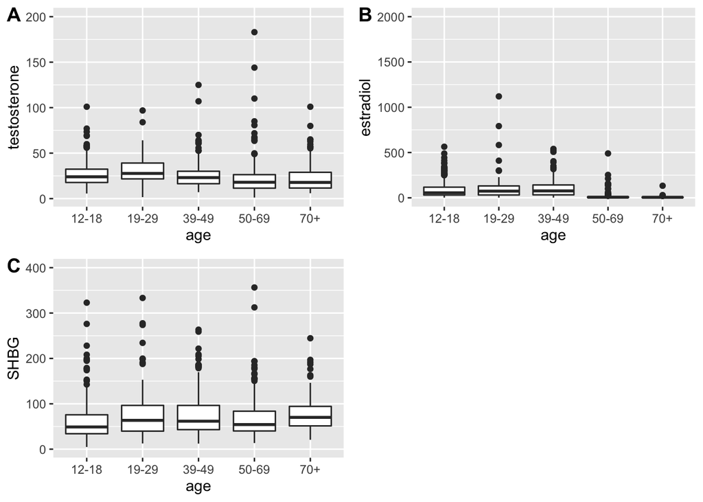

```r
library(ggplot2)
library(cowplot)
# Box plots and corresponding linear regression results for age, race, BMI, smoke, alcohol, and activity
g1 <- ggplot(data = nhanes, aes(x = age, y = testosterone)) + geom_boxplot() + ylim(c(1, 200))
g2 <- ggplot(data = nhanes, aes(x = age, y = estradiol)) + geom_boxplot() + ylim(c(1, 2000))
g3 <- ggplot(data = nhanes, aes(x = age, y = SHBG)) + geom_boxplot() + ylim(c(1, 400))

plot_grid(g1, g2, g3, labels = "AUTO")
```

```r
summary(lm(testosterone ~ age, data = nhanes))
```

```
##
## Call:
## lm(formula = testosterone ~ age, data = nhanes)
##
## Residuals:
## Testosterone, total (ng/dL)
##    Min     1Q Median     3Q    Max
## -29.70  -9.86  -3.76   5.68 420.68
##
## Coefficients:
##             Estimate Std. Error t value Pr(>|t|)
## (Intercept)  26.2789     1.0106  26.004   <2e-16 ***
## age19-29      5.0343     2.3155   2.174   0.0299 *
## age39-49     -0.5374     1.6891  -0.318   0.7504
## age50-69     -2.9561     1.5471  -1.911   0.0563 .
## age70+       -3.1456     2.1416  -1.469   0.1422
## ---
## Signif. codes:  0 '***' 0.001 '**' 0.01 '*' 0.05 '.' 0.1 ' ' 1
##
## Residual standard error: 19.98 on 1099 degrees of freedom
## Multiple R-squared:  0.01208,    Adjusted R-squared:  0.008483
## F-statistic: 3.359 on 4 and 1099 DF,  p-value: 0.009612
```

```r
summary(lm(estradiol ~ age, data = nhanes))
```

```
##
## Call:
## lm(formula = estradiol ~ age, data = nhanes)
##
## Residuals:
## Estradiol (pg/mL)
##    Min     1Q Median     3Q    Max
## -335.4  -57.4  -10.4    0.7 8772.5
##
## Coefficients:
##             Estimate Std. Error t value Pr(>|t|)
## (Intercept)    87.33      19.79   4.412 1.13e-05 ***
## age19-29      250.22      45.35   5.517 4.30e-08 ***
## age39-49       39.01      33.08   1.179   0.2386
## age50-69      -73.05      30.30  -2.411   0.0161 *
## age70+        -79.61      41.95  -1.898   0.0580 .
## ---
## Signif. codes:  0 '***' 0.001 '**' 0.01 '*' 0.05 '.' 0.1 ' ' 1
##
## Residual standard error: 391.4 on 1099 degrees of freedom
## Multiple R-squared:  0.04727,    Adjusted R-squared:  0.0438
## F-statistic: 13.63 on 4 and 1099 DF,  p-value: 7.501e-11
```

```r
summary(lm(SHBG ~ age, data = nhanes))
```

```
##
## Call:
## lm(formula = SHBG ~ age, data = nhanes)
##
## Residuals:
## SHBG (nmol/L)
##    Min     1Q Median     3Q    Max
## -86.62 -31.11 -13.66  16.46 514.56
##
## Coefficients:
##             Estimate Std. Error t value Pr(>|t|)
## (Intercept)   61.372      2.703  22.709  < 2e-16 ***
## age19-29      37.863      6.192   6.114 1.34e-09 ***
## age39-49      17.164      4.517   3.800 0.000153 ***
## age50-69       5.479      4.137   1.324 0.185650
## age70+        18.293      5.727   3.194 0.001443 **
## ---
## Signif. codes:  0 '***' 0.001 '**' 0.01 '*' 0.05 '.' 0.1 ' ' 1
##
## Residual standard error: 53.44 on 1099 degrees of freedom
## Multiple R-squared:  0.04134,    Adjusted R-squared:  0.03785
## F-statistic: 11.85 on 4 and 1099 DF,  p-value: 1.997e-09
```

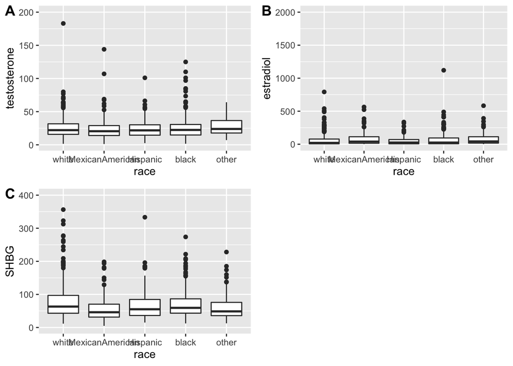

```r
r1 <- ggplot(data = nhanes, aes(x = race, y = testosterone)) + geom_boxplot() + ylim(c(1, 200))
r2 <- ggplot(data = nhanes, aes(x = race, y = estradiol)) + geom_boxplot() + ylim(c(1, 2000))
r3 <- ggplot(data = nhanes, aes(x = race, y = SHBG)) + geom_boxplot() + ylim(c(1, 400))

plot_grid(r1, r2, r3, labels = "AUTO")
```

```r
summary(lm(testosterone ~ race, data = nhanes))
```

```
##
## Call:
## lm(formula = testosterone ~ race, data = nhanes)
##
## Residuals:
## Testosterone, total (ng/dL)
##    Min     1Q Median     3Q    Max
## -24.41 -10.12  -3.46   5.61 418.08
##
## Coefficients:
##                     Estimate Std. Error t value Pr(>|t|)
## (Intercept)          25.9167     0.9673  26.793   <2e-16 ***
## raceMexicanAmerican  -2.1329     1.7270  -1.235    0.217
## raceHispanic         -1.3260     2.0035  -0.662    0.508
## raceblack             0.1027     1.6261   0.063    0.950
## raceother             0.9451     2.1529   0.439    0.661
## ---
## Signif. codes:  0 '***' 0.001 '**' 0.01 '*' 0.05 '.' 0.1 ' ' 1
##
## Residual standard error: 20.08 on 1099 degrees of freedom
## Multiple R-squared:  0.002317,   Adjusted R-squared:  -0.001314
## F-statistic: 0.638 on 4 and 1099 DF,  p-value: 0.6355
```

```r
summary(lm(estradiol ~ race, data = nhanes))
```

```
##
## Call:
## lm(formula = estradiol ~ race, data = nhanes)
##
## Residuals:
## Estradiol (pg/mL)
##    Min     1Q Median     3Q    Max
## -138.1  -71.6  -54.1    0.9 8969.8
##
## Coefficients:
##                     Estimate Std. Error t value Pr(>|t|)
## (Intercept)          73.7354    19.2852   3.823 0.000139 ***
## raceMexicanAmerican   0.3527    34.4326   0.010 0.991830
## raceHispanic         66.4539    39.9444   1.664 0.096465 .
## raceblack            29.3404    32.4213   0.905 0.365678
## raceother             6.0264    42.9247   0.140 0.888375
## ---
## Signif. codes:  0 '***' 0.001 '**' 0.01 '*' 0.05 '.' 0.1 ' ' 1
##
## Residual standard error: 400.4 on 1099 degrees of freedom
## Multiple R-squared:  0.003075,   Adjusted R-squared:  -0.0005537
## F-statistic: 0.8474 on 4 and 1099 DF,  p-value: 0.4952
```

```r
summary(lm(SHBG ~ race, data = nhanes))
```

```
##
## Call:
## lm(formula = SHBG ~ race, data = nhanes)
##
## Residuals:
## SHBG (nmol/L)
##    Min     1Q Median     3Q    Max
## -67.53 -31.69 -13.87  15.32 520.45
##
## Coefficients:
##                     Estimate Std. Error t value Pr(>|t|)
## (Intercept)           79.123      2.590  30.548  < 2e-16 ***
## raceMexicanAmerican  -24.364      4.625  -5.268 1.66e-07 ***
## raceHispanic          -2.953      5.365  -0.550  0.58211
## raceblack             -6.477      4.354  -1.488  0.13715
## raceother            -18.480      5.765  -3.206  0.00139 **
## ---
## Signif. codes:  0 '***' 0.001 '**' 0.01 '*' 0.05 '.' 0.1 ' ' 1
##
## Residual standard error: 53.77 on 1099 degrees of freedom
## Multiple R-squared:  0.02938,    Adjusted R-squared:  0.02585
## F-statistic: 8.316 on 4 and 1099 DF,  p-value: 1.313e-06
```

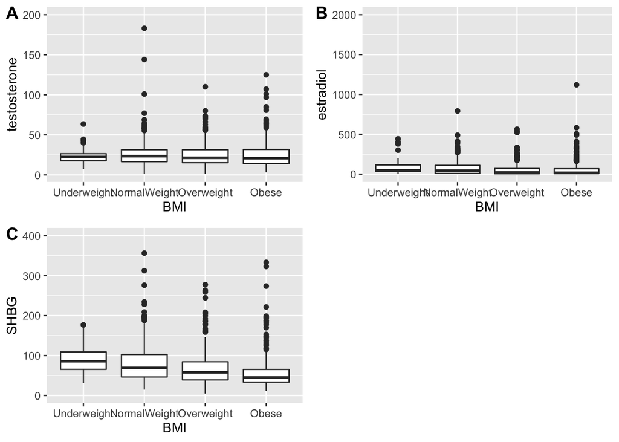

```r
b1 <- ggplot(data = nhanes, aes(x = BMI, y = testosterone)) + geom_boxplot() + ylim(c(1, 200))
b2 <- ggplot(data = nhanes, aes(x = BMI, y = estradiol)) + geom_boxplot() + ylim(c(1, 2000))
b3 <- ggplot(data = nhanes, aes(x = BMI, y = SHBG)) + geom_boxplot() + ylim(c(1, 400))

plot_grid(b1, b2, b3, labels = "AUTO")
```

```r
summary(lm(testosterone ~ BMI, data = nhanes))
```

```
##
## Call:
## lm(formula = testosterone ~ BMI, data = nhanes)
##
## Residuals:
## Testosterone, total (ng/dL)
##    Min     1Q Median     3Q    Max
## -24.64 -10.58  -3.39   5.88 417.92
##
## Coefficients:
##                 Estimate Std. Error t value Pr(>|t|)
## (Intercept)       23.168      2.733   8.478   <2e-16 ***
## BMINormalWeight    2.668      2.933   0.910    0.363
## BMIOverweight      1.517      2.976   0.510    0.610
## BMIObese           2.915      2.909   1.002    0.317
## ---
## Signif. codes:  0 '***' 0.001 '**' 0.01 '*' 0.05 '.' 0.1 ' ' 1
##
## Residual standard error: 20.08 on 1100 degrees of freedom
## Multiple R-squared:  0.001494,   Adjusted R-squared:  -0.001229
## F-statistic: 0.5488 on 3 and 1100 DF,  p-value: 0.649
```

```r
summary(lm(estradiol ~ BMI, data = nhanes))
```

```
##
## Call:
## lm(formula = estradiol ~ BMI, data = nhanes)
##
## Residuals:
## Estradiol (pg/mL)
##    Min     1Q Median     3Q    Max
## -119.9  -76.8  -49.7    3.7 8988.0
##
## Coefficients:
##                 Estimate Std. Error t value Pr(>|t|)
## (Intercept)        92.08      54.42   1.692   0.0909 .
## BMINormalWeight   -16.60      58.41  -0.284   0.7763
## BMIOverweight     -34.91      59.27  -0.589   0.5560
## BMIObese           29.91      57.93   0.516   0.6057
## ---
## Signif. codes:  0 '***' 0.001 '**' 0.01 '*' 0.05 '.' 0.1 ' ' 1
##
## Residual standard error: 399.9 on 1100 degrees of freedom
## Multiple R-squared:  0.004527,   Adjusted R-squared:  0.001812
## F-statistic: 1.667 on 3 and 1100 DF,  p-value: 0.1723
```

```r
summary(lm(SHBG ~ BMI, data = nhanes))
```

```
##
## Call:
## lm(formula = SHBG ~ BMI, data = nhanes)
##
## Residuals:
## SHBG (nmol/L)
##    Min     1Q Median     3Q    Max
## -69.06 -29.62 -12.93  13.75 533.26
##
## Coefficients:
##                 Estimate Std. Error t value Pr(>|t|)
## (Intercept)       91.961      7.269  12.651  < 2e-16 ***
## BMINormalWeight   -8.167      7.803  -1.047  0.29543
## BMIOverweight    -24.121      7.917  -3.047  0.00237 **
## BMIObese         -32.119      7.739  -4.150 3.57e-05 ***
## ---
## Signif. codes:  0 '***' 0.001 '**' 0.01 '*' 0.05 '.' 0.1 ' ' 1
##
## Residual standard error: 53.42 on 1100 degrees of freedom
## Multiple R-squared:  0.04126,    Adjusted R-squared:  0.03865
## F-statistic: 15.78 on 3 and 1100 DF,  p-value: 4.72e-10
```

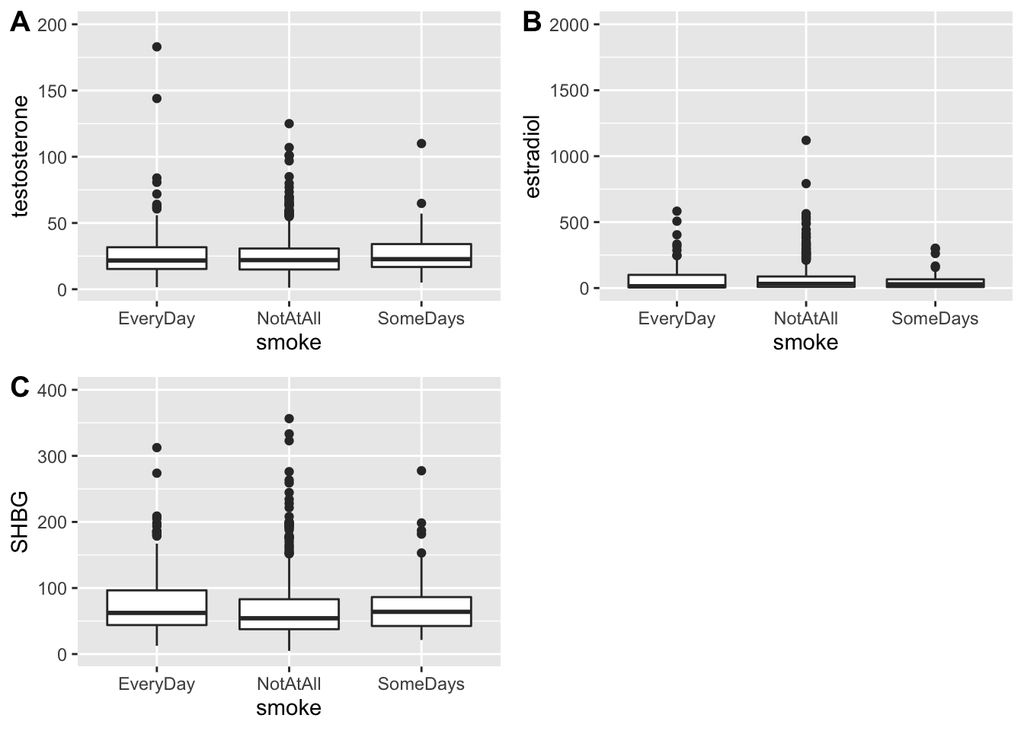

```r
s1 <- ggplot(data = nhanes, aes(x = smoke, y = testosterone)) + geom_boxplot() + ylim(c(1, 200))
s2 <- ggplot(data = nhanes, aes(x = smoke, y = estradiol)) + geom_boxplot() + ylim(c(1, 2000))
s3 <- ggplot(data = nhanes, aes(x = smoke, y = SHBG)) + geom_boxplot() + ylim(c(1, 400))

plot_grid(s1, s2, s3, labels = "AUTO")
```

```r
summary(lm(testosterone ~ smoke, data = nhanes))
```

```
##
## Call:
## lm(formula = testosterone ~ smoke, data = nhanes)
##
## Residuals:
## Testosterone, total (ng/dL)
##    Min     1Q Median     3Q    Max
## -25.90 -10.46  -3.46   5.64 416.58
##
## Coefficients:
##               Estimate Std. Error t value Pr(>|t|)
## (Intercept)    27.4180     1.2484  21.962   <2e-16 ***
## smokeNotAtAll  -2.6588     1.4395  -1.847    0.065 .
## smokeSomeDays  -0.6706     2.8180  -0.238    0.812
## ---
## Signif. codes:  0 '***' 0.001 '**' 0.01 '*' 0.05 '.' 0.1 ' ' 1
##
## Residual standard error: 20.05 on 1101 degrees of freedom
## Multiple R-squared:  0.003325,   Adjusted R-squared:  0.001514
## F-statistic: 1.836 on 2 and 1101 DF,  p-value: 0.1599
```

```r
summary(lm(estradiol ~ smoke, data = nhanes))
```

```
##
## Call:
## lm(formula = estradiol ~ smoke, data = nhanes)
##
## Residuals:
## Estradiol (pg/mL)
##    Min     1Q Median     3Q    Max
## -102.6  -79.9  -52.9    2.1 9005.3
##
## Coefficients:
##               Estimate Std. Error t value Pr(>|t|)
## (Intercept)     104.73      24.93   4.201 2.88e-05 ***
## smokeNotAtAll   -18.63      28.75  -0.648    0.517
## smokeSomeDays   -51.90      56.28  -0.922    0.357
## ---
## Signif. codes:  0 '***' 0.001 '**' 0.01 '*' 0.05 '.' 0.1 ' ' 1
##
## Residual standard error: 400.5 on 1101 degrees of freedom
## Multiple R-squared:  0.0008639,  Adjusted R-squared:  -0.0009511
## F-statistic: 0.476 on 2 and 1101 DF,  p-value: 0.6214
```

```r
summary(lm(SHBG ~ smoke, data = nhanes))
```

```
##
## Call:
## lm(formula = SHBG ~ smoke, data = nhanes)
##
## Residuals:
## SHBG (nmol/L)
##    Min     1Q Median     3Q    Max
## -65.92 -32.06 -14.32  15.75 525.18
##
## Coefficients:
##               Estimate Std. Error t value Pr(>|t|)
## (Intercept)     78.530      3.379  23.238  < 2e-16 ***
## smokeNotAtAll  -10.612      3.896  -2.723  0.00656 **
## smokeSomeDays    3.732      7.628   0.489  0.62480
## ---
## Signif. codes:  0 '***' 0.001 '**' 0.01 '*' 0.05 '.' 0.1 ' ' 1
##
## Residual standard error: 54.28 on 1101 degrees of freedom
## Multiple R-squared:  0.009165,   Adjusted R-squared:  0.007365
## F-statistic: 5.092 on 2 and 1101 DF,  p-value: 0.006292
```

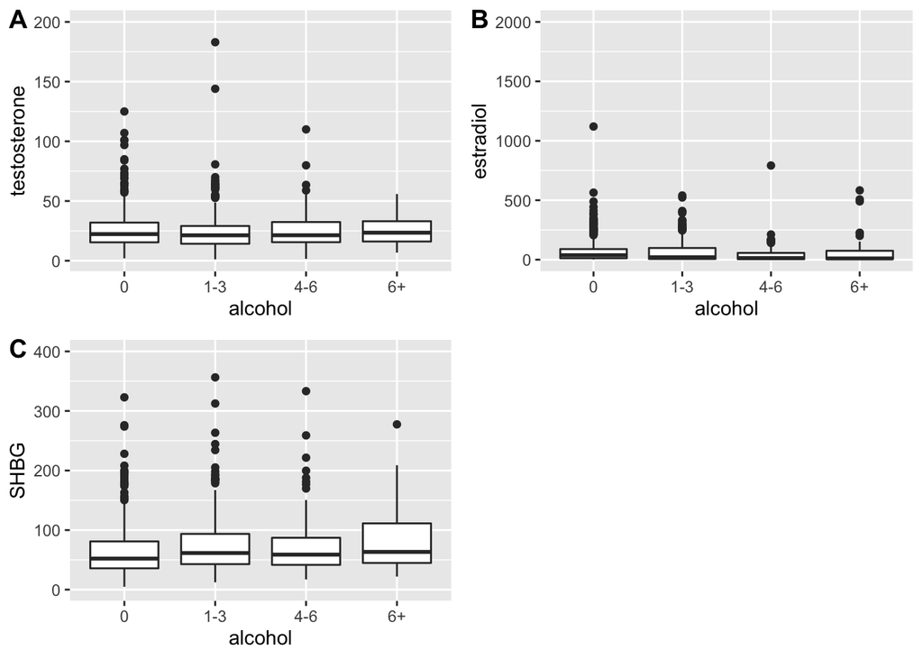

```r
h1 <- ggplot(data = nhanes, aes(x = alcohol, y = testosterone)) + geom_boxplot() + ylim(c(1, 200))
h2 <- ggplot(data = nhanes, aes(x = alcohol, y = estradiol)) + geom_boxplot() + ylim(c(1, 2000))
h3 <- ggplot(data = nhanes, aes(x = alcohol, y = SHBG)) + geom_boxplot() + ylim(c(1, 400))

plot_grid(h1, h2, h3, labels = "AUTO")
```

```r
summary(lm(testosterone ~ alcohol, data = nhanes))
```

```
##
## Call:
## lm(formula = testosterone ~ alcohol, data = nhanes)
##
## Residuals:
## Testosterone, total (ng/dL)
##    Min     1Q Median     3Q    Max
## -24.29 -10.36  -3.58   5.82 418.51
##
## Coefficients:
##             Estimate Std. Error t value Pr(>|t|)
## (Intercept) 25.56228    0.84765  30.157   <2e-16 ***
## alcohol1-3  -0.07122    1.33565  -0.053    0.957
## alcohol4-6  -0.12880    2.07940  -0.062    0.951
## alcohol6+   -0.66581    2.93874  -0.227    0.821
## ---
## Signif. codes:  0 '***' 0.001 '**' 0.01 '*' 0.05 '.' 0.1 ' ' 1
##
## Residual standard error: 20.09 on 1100 degrees of freedom
## Multiple R-squared:  4.782e-05,  Adjusted R-squared:  -0.002679
## F-statistic: 0.01754 on 3 and 1100 DF,  p-value: 0.9968
```

```r
summary(lm(estradiol ~ alcohol, data = nhanes))
```

```
##
## Call:
## lm(formula = estradiol ~ alcohol, data = nhanes)
##
## Residuals:
## Estradiol (pg/mL)
##    Min     1Q Median     3Q    Max
## -128.5  -77.4  -55.2    3.4 9011.0
##
## Coefficients:
##             Estimate Std. Error t value Pr(>|t|)
## (Intercept)    99.01      16.88   5.865 5.94e-09 ***
## alcohol1-3    -36.01      26.60  -1.354    0.176
## alcohol4-6     31.59      41.41   0.763    0.446
## alcohol6+     -28.16      58.53  -0.481    0.631
## ---
## Signif. codes:  0 '***' 0.001 '**' 0.01 '*' 0.05 '.' 0.1 ' ' 1
##
## Residual standard error: 400.2 on 1100 degrees of freedom
## Multiple R-squared:  0.002959,   Adjusted R-squared:  0.0002402
## F-statistic: 1.088 on 3 and 1100 DF,  p-value: 0.353
```

```r
summary(lm(SHBG ~ alcohol, data = nhanes))
```

```
##
## Call:
## lm(formula = SHBG ~ alcohol, data = nhanes)
##
## Residuals:
## SHBG (nmol/L)
##    Min     1Q Median     3Q    Max
## -63.24 -31.61 -14.57  15.62 527.42
##
## Coefficients:
##             Estimate Std. Error t value Pr(>|t|)
## (Intercept)   65.684      2.287  28.718  < 2e-16 ***
## alcohol1-3     9.364      3.604   2.598  0.00949 **
## alcohol4-6    14.716      5.611   2.623  0.00884 **
## alcohol6+     17.857      7.929   2.252  0.02452 *
## ---
## Signif. codes:  0 '***' 0.001 '**' 0.01 '*' 0.05 '.' 0.1 ' ' 1
##
## Residual standard error: 54.22 on 1100 degrees of freedom
## Multiple R-squared:  0.01221,    Adjusted R-squared:  0.009511
## F-statistic: 4.531 on 3 and 1100 DF,  p-value: 0.003646
```

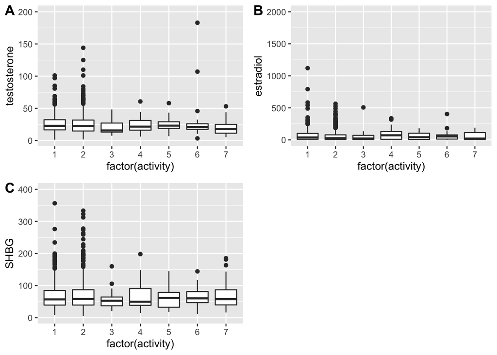

```r
a1 <- ggplot(data = nhanes, aes(x = factor(activity), y = testosterone)) + geom_boxplot() + ylim(c(1, 200))
a2 <- ggplot(data = nhanes, aes(x = factor(activity), y = estradiol)) + geom_boxplot() + ylim(c(1, 2000))
a3 <- ggplot(data = nhanes, aes(x = factor(activity), y = SHBG)) + geom_boxplot() + ylim(c(1, 400))

plot_grid(a1, a2, a3, labels = "AUTO")
```

```r
summary(lm(testosterone ~ activity, data = nhanes))
```

```
##
## Call:
## lm(formula = testosterone ~ activity, data = nhanes)
##
## Residuals:
## Testosterone, total (ng/dL)
##    Min     1Q Median     3Q    Max
## -24.83 -10.37  -3.35   5.76 418.43
##
## Coefficients:
##             Estimate Std. Error t value Pr(>|t|)
## (Intercept)  26.4799     1.1081  23.896   <2e-16 ***
## activity     -0.4526     0.4265  -1.061    0.289
## ---
## Signif. codes:  0 '***' 0.001 '**' 0.01 '*' 0.05 '.' 0.1 ' ' 1
##
## Residual standard error: 20.07 on 1102 degrees of freedom
## Multiple R-squared:  0.001021,   Adjusted R-squared:  0.0001143
## F-statistic: 1.126 on 1 and 1102 DF,  p-value: 0.2888
```

```r
summary(lm(estradiol ~ activity, data = nhanes))
```

```
##
## Call:
## lm(formula = estradiol ~ activity, data = nhanes)
##
## Residuals:
## Estradiol (pg/mL)
##    Min     1Q Median     3Q    Max
##  -94.3  -82.1  -56.0    4.2 9020.3
##
## Coefficients:
##             Estimate Std. Error t value Pr(>|t|)
## (Intercept)  103.006     22.107   4.659 3.56e-06 ***
## activity      -6.635      8.508  -0.780    0.436
## ---
## Signif. codes:  0 '***' 0.001 '**' 0.01 '*' 0.05 '.' 0.1 ' ' 1
##
## Residual standard error: 400.3 on 1102 degrees of freedom
## Multiple R-squared:  0.0005516,  Adjusted R-squared:  -0.0003553
## F-statistic: 0.6082 on 1 and 1102 DF,  p-value: 0.4356
```

```r
summary(lm(SHBG ~ activity, data = nhanes))
```

```
##
## Call:
## lm(formula = SHBG ~ activity, data = nhanes)
##
## Residuals:
## SHBG (nmol/L)
##    Min     1Q Median     3Q    Max
## -66.47 -31.89 -13.45  15.40 521.82
##
## Coefficients:
##             Estimate Std. Error t value Pr(>|t|)
## (Intercept)  72.0100     3.0097  23.926   <2e-16 ***
## activity     -0.3643     1.1584  -0.314    0.753
## ---
## Signif. codes:  0 '***' 0.001 '**' 0.01 '*' 0.05 '.' 0.1 ' ' 1
##
## Residual standard error: 54.5 on 1102 degrees of freedom
## Multiple R-squared:  8.975e-05,  Adjusted R-squared:  -0.0008176
## F-statistic: 0.09891 on 1 and 1102 DF,  p-value: 0.7532
```